# Exploring the Africa Soil Property Prediction Challenge Data Set

Adeyemi Arogunmati

May 29, 2016

## Introduction

In my quest to build prediction models for the Kaggle Africa Soil Property Prediction Challenge described in detail at https://www.kaggle.com/c/afsis-soil-properties, I would like to understand the data. I want to find and quantify relationships between variables and also search for trends to support my expectation that the provided data can be used to build a good prediction model. In the following sections, I detail the steps i take to achieve my set goals.

## Data Loading, Cleaning and Manipulation

### Data Loading

The data set is readily available at the Kaggle competition website https://www.kaggle.com/c/afsis-soil-properties/data. This data set comes in zipped csv format and is essentially clean. Column headers are as follows:

- **PIDN:** unique soil sample identifier
- **SOC:** Soil organic carbon
- **pH:** pH values
- **Ca:** Mehlich-3 extractable Calcium
- **P:** Mehlich-3 extractable Phosphorus
- **Sand:** Sand content
- **m7497.96 - m599.76:** 3578 mid-infrared absorbance measurements
- **Depth:** Depth of the soil sample (2 categories: “Topsoil”, “Subsoil”)
- BSA: average long-term Black Sky Albedo measurements from MODIS satellite images (**BSAN** = near-infrared, **BSAS** = shortwave, **BSAV** = visible)
- **CTI:** compound topographic index calculated from Shuttle Radar Topography Mission elevation data
- **ELEV:** Shuttle Radar Topography Mission elevation data
- **EVI:** average long-term Enhanced Vegetation Index from MODIS satellite images.
- LST: average long-term Land Surface Temperatures from MODIS satellite images (**LSTD** = day time temperature, **LSTN** = night time temperature)
- REF: average long-term Reflectance measurements from MODIS satellite images (**REF1** = blue, **REF2** = red, **REF3** = near-infrared, **REF7** = mid-infrared)
- **RELI:** topographic Relief calculated from Shuttle Radar Topography mission elevation data
- **TMAP & TMFI:** average long-term Tropical Rainfall Monitoring Mission data (TMAP = mean annual precipitation, TMFI = modified Fournier index)

Columns SOC, pH, Ca, P, and Sand are the five (5) outcome variables to be predicted by our final prediction model.

```r
data0 <- read.csv(unz("data_and_codes/train.zip","training.csv"), na.strings=c("NA",""))
```

The loaded data frame has 1157 rows or observations and 3600 columns or variables; one (1) id variable, five (5) outcome variables, and 3594 predictor variables.

### Cleaning and Manipulation

There are a total of 3578 mid-infrared absorbance measurements. As per the competition suggestion, we should “remove spectra CO2 bands which are in the region m2379.76 to m2352.76”. I extract the columns corresponding to the spectral data into its own data.frame since we will perform some pre-processing on them.

```r
a <- grep("m2379.76",names(data0))
b <- grep("m2352.76",names(data0))

data <- data0[,-seq(a,b)]

## Create spectra-only data subset
infraredCols <- grep("^m[0-9].*?\\.[0-9].*",names(data))
infraredData <- data.frame(data[,infraredCols])

## Create new data frame for plotting
vec <- seq(1,nrow(infraredData))
plotData <- data.frame(infraredData,Index=vec)
```

There are 15 CO$_2$ bands to be removed. This brings the number of mid-infrared absorbance measurements variables to 3563. Together with additional 16 predictor variables, we have a total of 3579 predictor variables.

## Data Exploration

### 1. How do soil properties vary with depth?

This question can easily be answered by assessing the distributions of each outcome variable by depth.

| Variable | Mean.Topsoil | Mean.Subsoil | Sd.Topsoil | Sd.Subsoil |
| --- | --- | --- | --- | --- |
| Sand | 0.03 | -0.05 | 0.97 | 1.01 |
| Ca | 0 | 0.01 | 1 | 1.13 |
| P | 0.07 | -0.1 | 0.93 | 1.05 |
| pH | 0 | -0.06 | 0.86 | 0.98 |
| SOC | 0.25 | -0.09 | 1.21 | 1.04 |

Table 1 shows that variations in distributions of outcome variables Sand, Ca, P, SOC and pH, with depth exist, but are not alarmingly different.

### 2. How do spectral signatures vary from site to site?

To answer this question, I select overlay plots of spectral signatures at multiple sites to search for similarities and differences. This will help in determining what kind of pre-processing we need to do to the data prior to modeling.

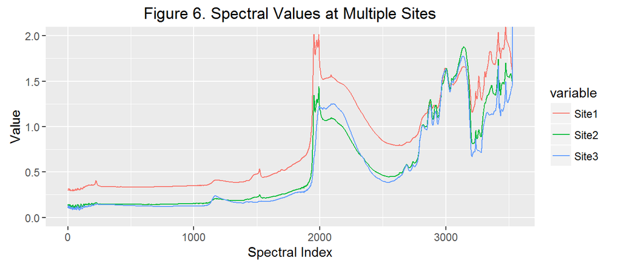

```r
library(reshape2)

## compare spectral data from multiple sites
pdata0 = data.frame(Spectral.Index=1:ncol(plotData),
                    Site1=as.vector(t(plotData[101,])),
                    Site2=as.vector(t(plotData[876,])),
                    Site3=as.vector(t(plotData[1074,])))
pdata1 <- melt(pdata0,id.vars = "Spectral.Index")
```

As Figure 6 shows, there is a clear pattern in the spectral signatures as we go from one index to the next and this is consistent from site to site. Also this plot supports the idea that we can treat each row of the data frame as a signal (think time series signal) and apply relevant data processing techniques to smooth, and compress our data without losing relevant detail.

### 3. Can we smooth and compress our data without losing relevant detail?

As mentioned in the previous section, I decided to treat the rows of my data frame as a signal and pre-process them accordingly. Here, I decimate the number of signal samples (columns of each row in my data frame containing only spectral data) by using the decimate function of the signal package. This function applies a infinite impulse response, or IIR filter (default), prior to decimation to avoid aliasing effects. This anti-aliasing ability is what allows us to decimate the signals while preserving the smallest detectable character in the signal at that scale reliably. In the next plot, I show resulting decimation plots from row 1 in my data frame.

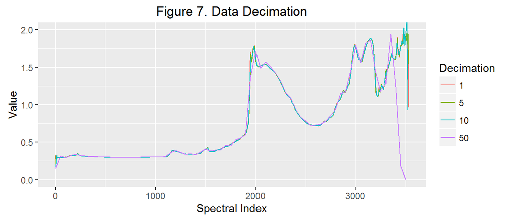

```r
suppressWarnings(suppressMessages(library(signal)))

siteNum <- 1
newVec  <- newIndex <- newVecId <- vector()
vec     <- as.vector(t(plotData[siteNum,]))

for (fac in c(1,5,10,50)) {
    newVec   <- c(newVec,decimate(vec,fac))
    newIndex <- c(newIndex,seq(1,length(vec),by=fac))
    newVecId <- c(newVecId,rep(fac,length(seq(1,length(vec),by=fac))))
}
pdata2 <- data.frame(index=newIndex,value=newVec,Decimation=factor(newVecId))
```

In Figure 7, decimation factors of 5 and 10 appear reasonable while decimation factor of 50 clearly mismatches the original (decimation factor of 1). We can even zoom tighter on the plot to show more detail.

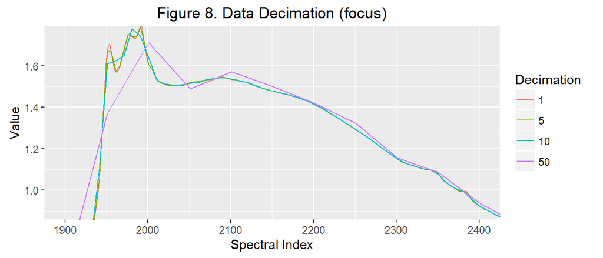

In Figure 8, we see that we lost significant detail with a decimation factor of 50 and some detail with a decimation factor of 10. However, not much is lost with a decimation factor of 5.

### 4. How much does spectral power change with prediction outcome variables? Can we detect dependencies?

In signal processing, we define the power of a signal as the sum of absolute squares of each sample divided by the signal length or number of samples. You can imagine power as a summary variable of the signal. In this section, we show relationships between outcome variables and color the plotted points by spectral power.This gives insight as to whether the outcomes are detectable given spectral data. Note that the spectral power used here were computed from the undecimated dataset.

The spectral powers calculated were divided into quartiles, and the resulting plots are shown below. What we will see is that there are relationships between the outcome variables and spectral measurements, which supports the claim that we can use the spectral measurements as good predictors of the outcome variables if sufficient training samples are available.

```r
signalPower <- apply(infraredData^2,1,sum)/ncol(infraredData)
signalPowerCut <- factor(cut(signalPower, quantile(signalPower, probs=0:4/4), include.lowest=TRUE))

outcomeCols <- grep("Sand|Ca|ph|^P$|SOC",names(data),ignore.case = TRUE)
pat <- "BSAN|BSAS|BSAV|CTI|ELEV|EVI|LSTD|LSTN|Ref1|Ref2|Ref3|Ref7|Reli|TMAP|TMFI|Depth"
varCols <- grep(pat,names(data),ignore.case = TRUE)

properties <- data.frame(data[,outcomeCols],data[,varCols],
                         Power=signalPower,Power.Quantile=signalPowerCut)
```

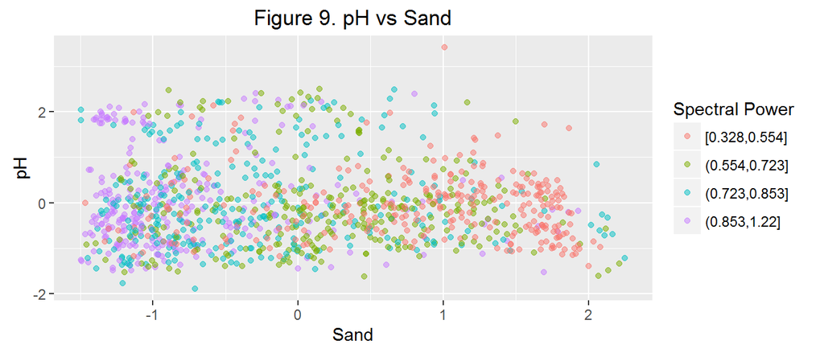

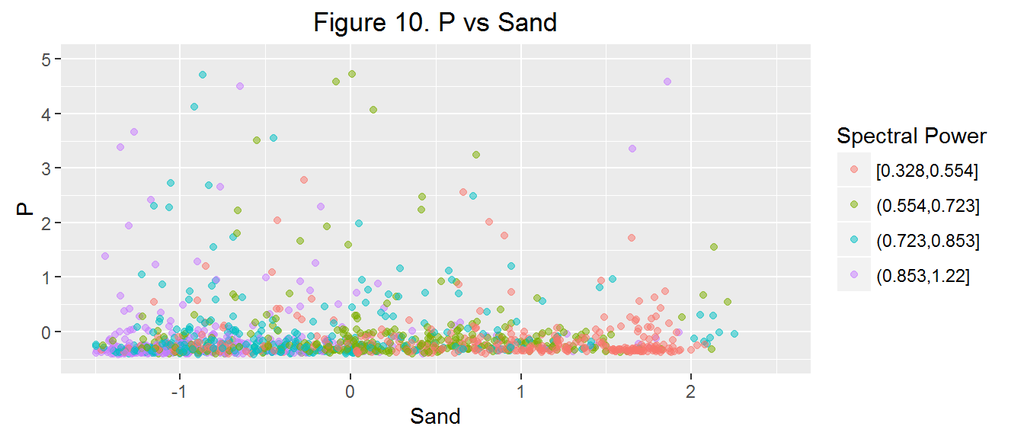

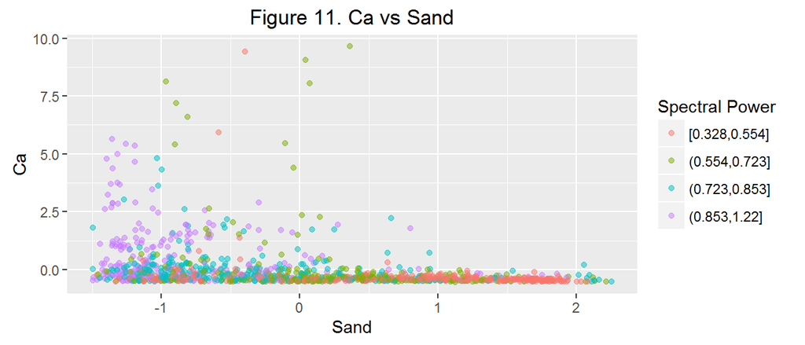

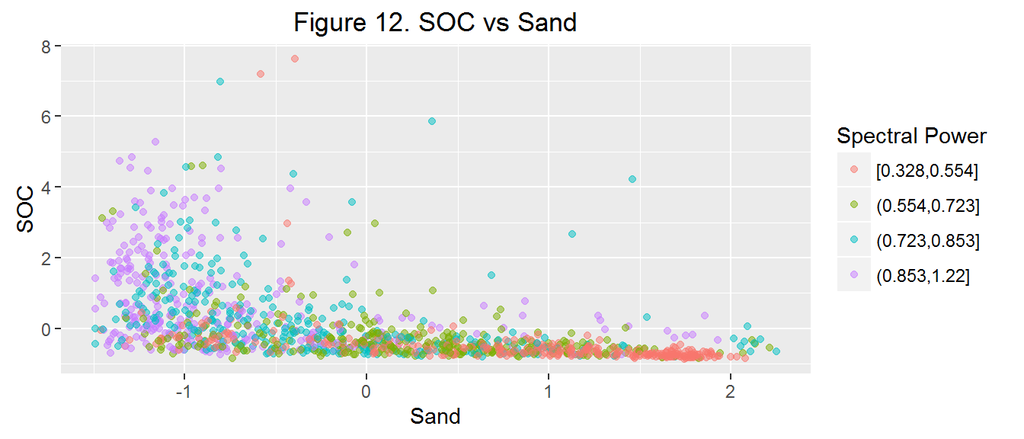

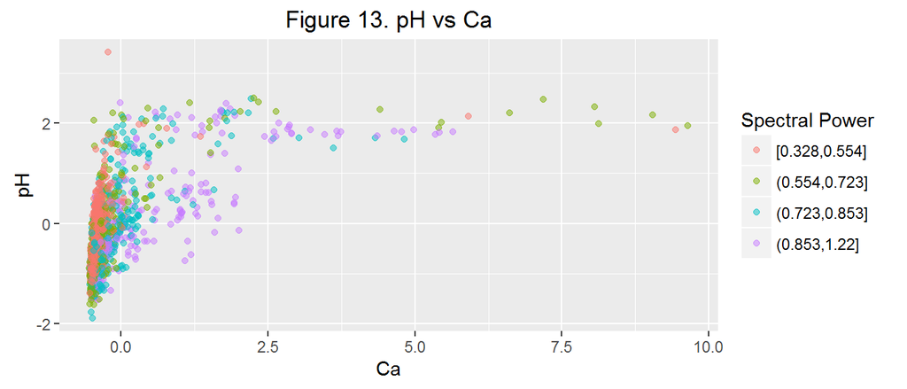

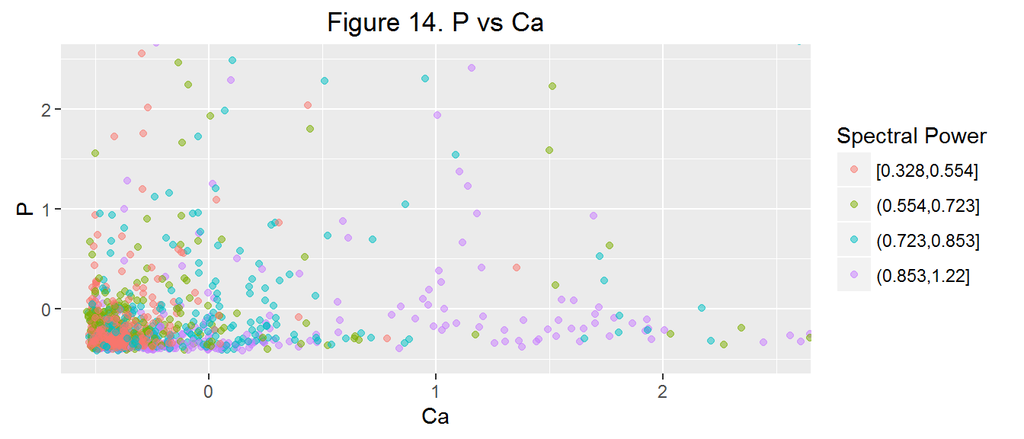

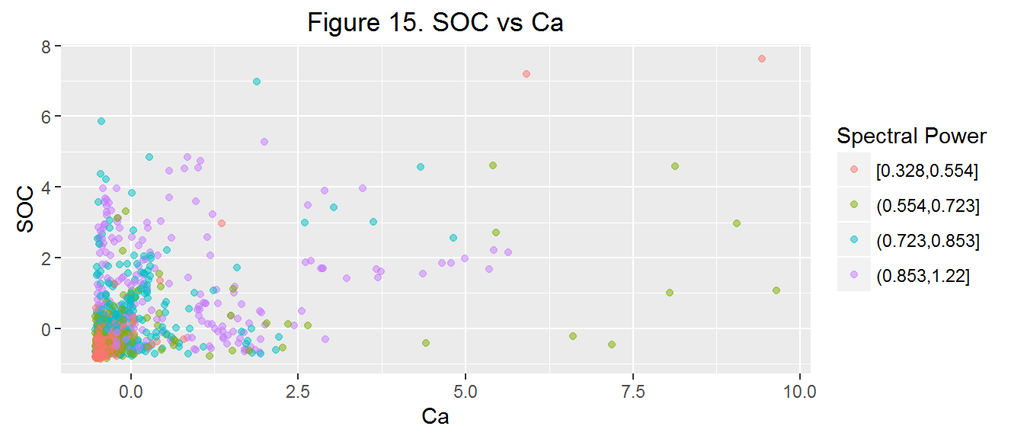

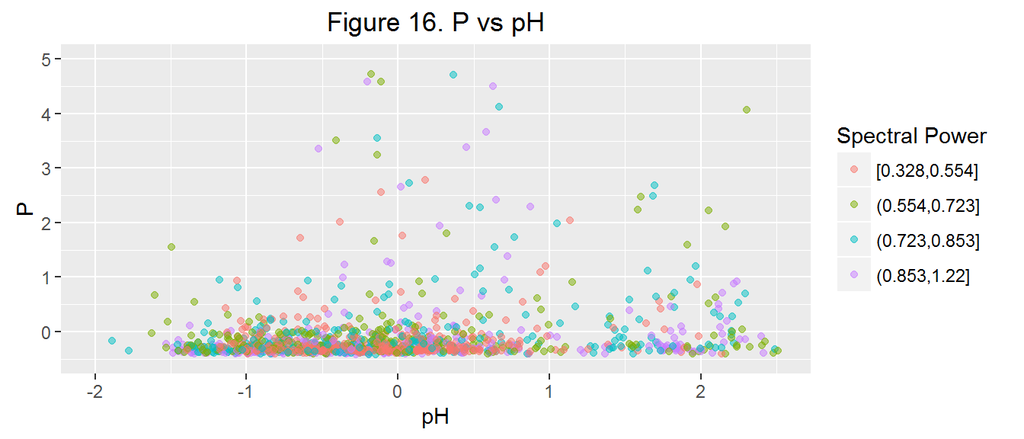

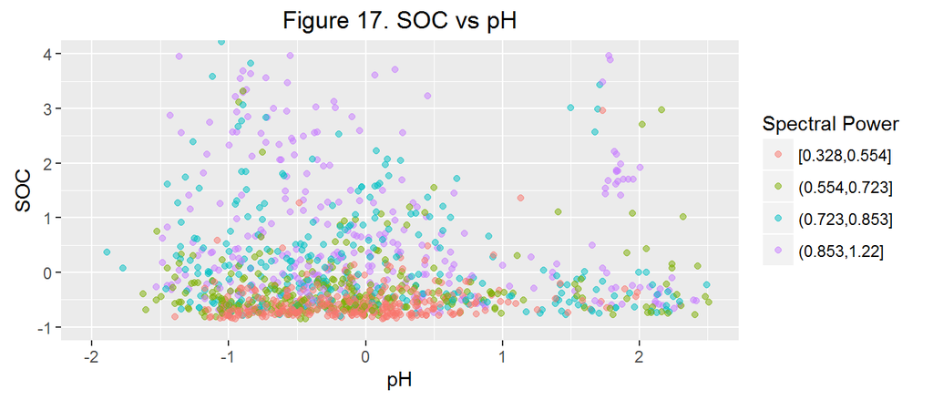

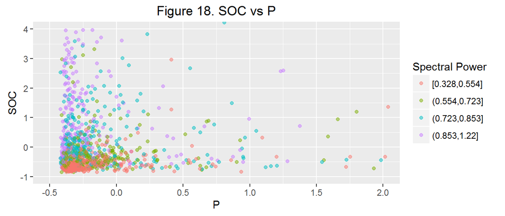

The next set of plots are violin plots showing the distributions of the outcome variables grouped by spectral power quartiles. These plots also support the claim that we can use the spectral measurements as good predictors of the outcome variables if sufficient training samples are available.

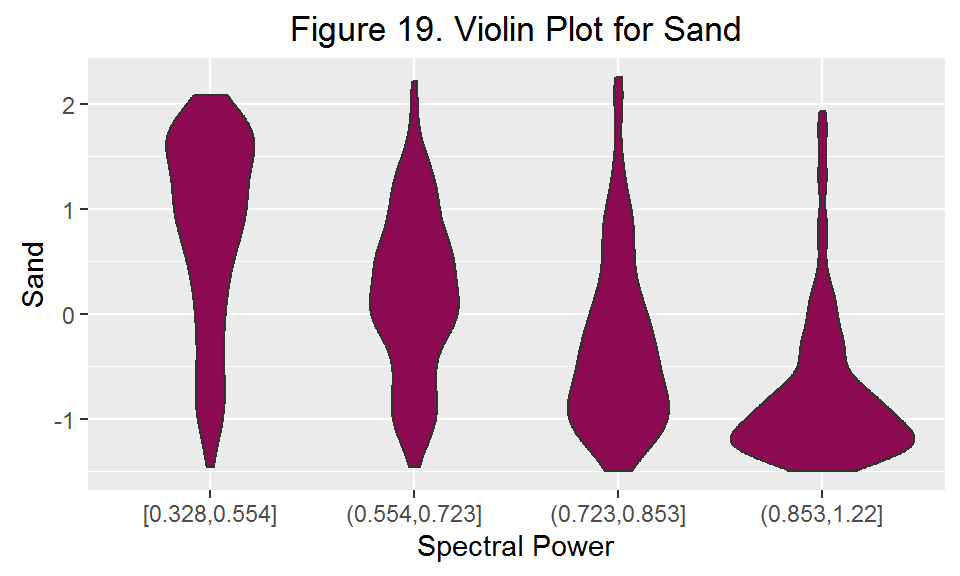

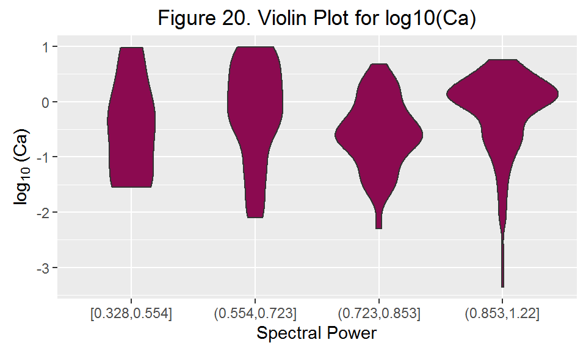

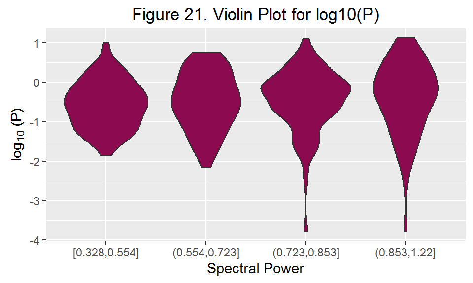

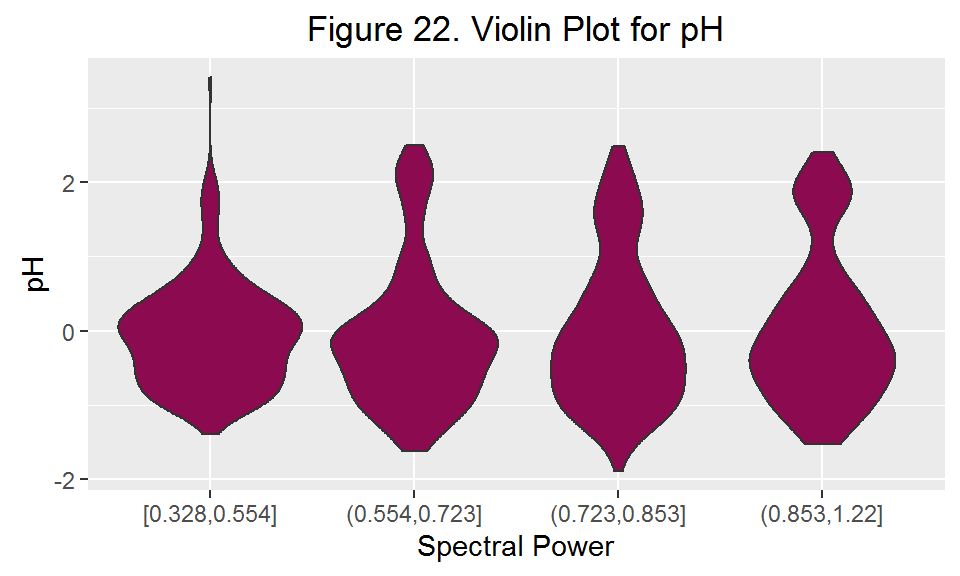

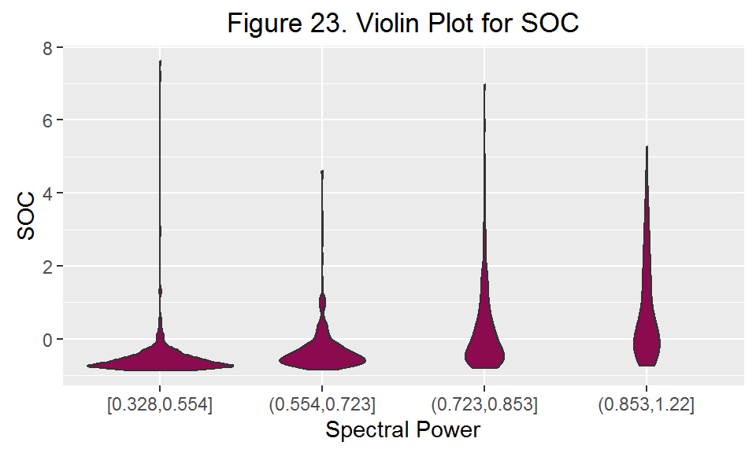

### 4. Additional potentially useful data were provided. Are these truly useful? What is the relationship between the outcome variables and these potentially useful data?

Additional data were provided with the expectation that they may be useful in building our prediction models. These are the data in the columns named **BSAN**, **BSAS**, **BSAV**, **CTI**, **ELEV**, **EVI**, **LSTD**, **LSTD**, **REF1**, **REF2**, **REF3**, **REF7**, **RELI**, **TMAP**, and **TMFI**. I would like to look for trends that suggest there are relationships between these predictor variables and the outcome variables.

One quick way to examine this is the plot cross correlation values of these variables and the outcome variables and look for values that suggest moderate to strong relationships.

```r
outcomeCols <- grep("Sand|Ca|ph|^P$|SOC",names(data),ignore.case = TRUE)
pat <- "BSAN|BSAS|BSAV|CTI|ELEV|EVI|LSTD|LSTN|Ref1|Ref2|Ref3|Ref7|Reli|TMAP|TMFI"
varCols <- grep(pat,names(data),ignore.case = TRUE)

n           <- length(outcomeCols)*length(varCols)
outcomeName <- character(n)
varName     <- character(n)
corVal      <- numeric(n)

k <- 1
for (i in outcomeCols) {
    for (j in varCols) {
        outcomeName[k] <- names(data)[i]
        varName[k]     <- names(data)[j]
        corVal[k]      <- cor(data[,i],data[,j])
        k <- k + 1
    }
}
dmat <- cbind(outcomeName,varName,corVal)
row.names(dmat) <- c(1:nrow(dmat))
df <- data.frame(dmat)
names(df) <- c("Outcome","Variable","Correlation")
df$Correlation <- as.numeric(as.character(df$Correlation))
```

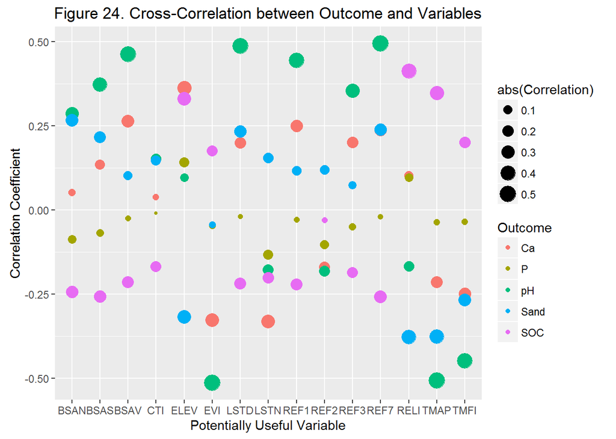

In Figure 24, we see that there is an absence of strong correlation between the outcome variables and the additional predictor variables. There are however, a few moderately correlated variables. These are pH and EVI, pH and TMAP, pH and LSTD, and pH and Ref7. While the outcome variable pH is the most correlated with these additional predictor variables, the outcome variable P is the least correlated.

Selected scatter plots for some of the points plotted in Figure 24 are shown below.

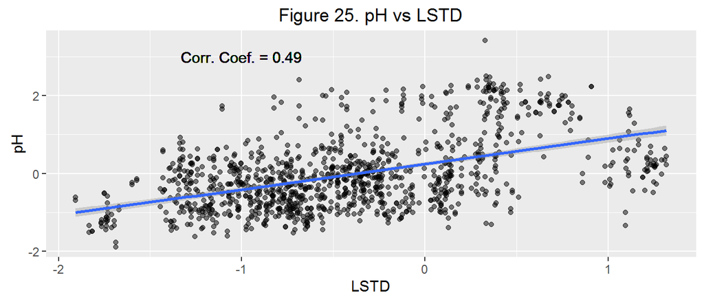

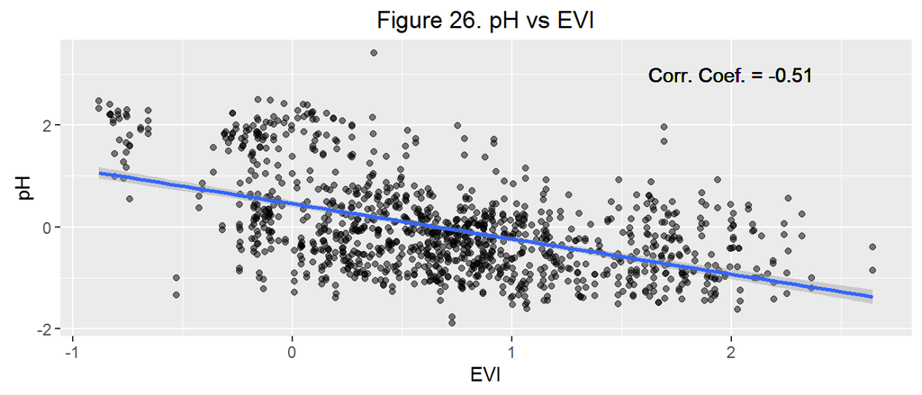

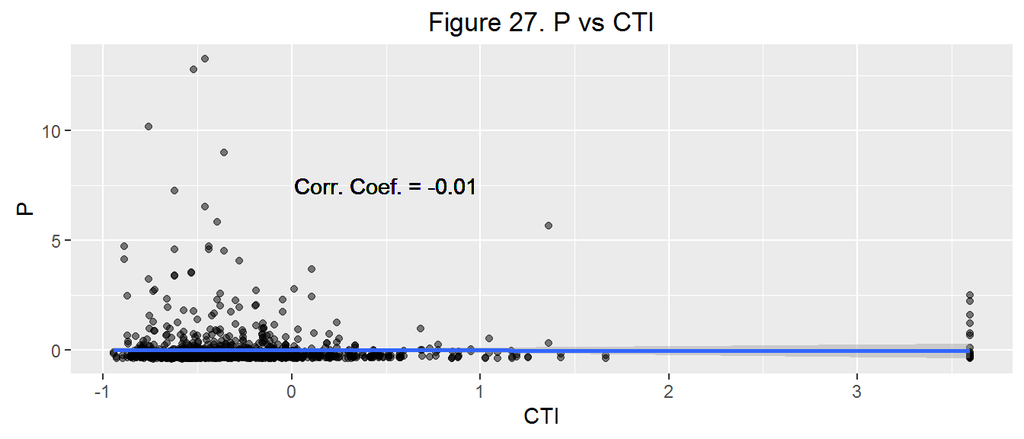

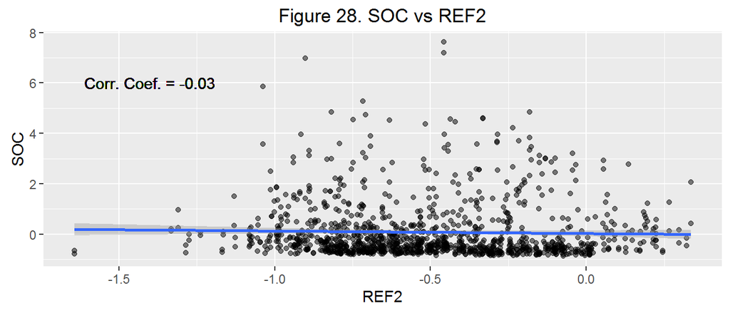

## Conclusions

Prior to building my prediction model for the Kaggle Africa Soil Property Prediction Challenge, I explored data set to get a good understanding of the relationship between outcome variables and predictor variables with the hope of finding trends that suggest that the prediction problem can be solved.

My exploratory data analysis shows discrimination of outcome variables by infrared spectral values. I also found that additional potentially useful datasets provided showed weak to no correlation with outcome variables except the pH outcome variable where moderate correlation are observed with EVI, TMAP, LSTD, and REF7.

The total number of predictor variables are 3579 and observations are 1157. I observed that the data set can be decimated without losing relevant detail. If the number of predictor variables is not reduced and a linear model is used for prediction, the resulting linear inverse system will be underdetermined. Regularization parameters will be useful in these cases.

There is a limit to how much the number of predictor variables can be reduced. With a decimation factor of 50, significant detail is lost. Also, a decimation factor of 10 loses some detail while a decimation factor of 5 loses minimal detail. For our prediction model, I suspect data sets compressed with a decimation factor of 5 or 10 will be adequate. We will have to run some tests to confirm this.